# RECAP: Linear regression with a single predictor

Lecture 15

2024-06-06

## Goals

- Review linear regression with a single predictor

## Setup

```r
library(tidyverse)
library(tidymodels)
```

# Linear regression with a single predictor

## Data overview

From the Fandango data set, we want to model `audience` movie ratings based on `critics` ratings.

```r
movie_scores |>
  select(critics, audience)
```

```
# A tibble: 146 × 2
   critics audience
     <int>    <int>
 1      74       86
 2      85       80
 3      80       90
 4      18       84
 5      14       28
 6      63       62
 7      42       53
 8      86       64
 9      99       82
10      89       87
# ℹ 136 more rows
```

## Regression model

A **simple linear regression model** is used to model the relationship between a quantitative outcome ($Y$) and a single quantitative predictor ($X$):
$$\Large{Y = \beta_0 + \beta_1 X +\epsilon}$$

- $\beta_1$: True slope of the relationship between $X$ and $Y$
- $\beta_0$: True intercept of the relationship between $X$ and $Y$
- $\epsilon$: Error term

## Fandango data: least squares line

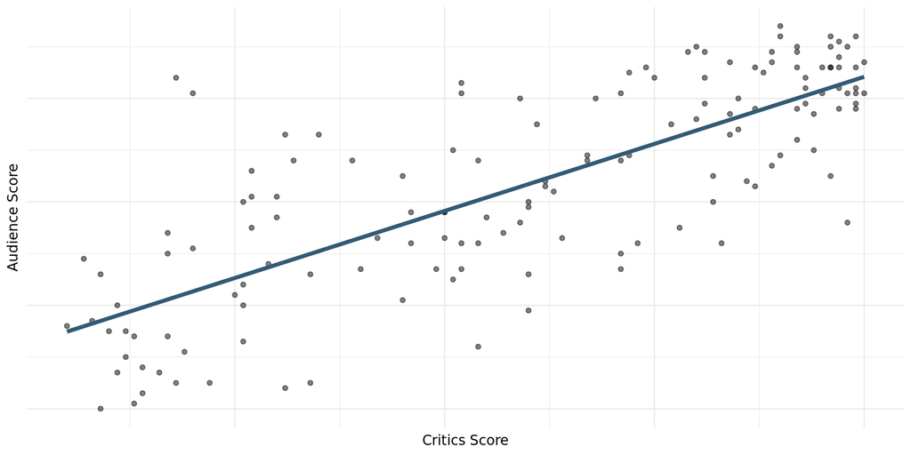

Where the solid line minimizes the sum of the squared residuals.

## Linear regression model output

```r
movies_fit <- linear_reg() |>
  fit(audience ~ critics, data = movie_scores)

tidy(movies_fit)
```

```
# A tibble: 2 × 5
  term        estimate std.error statistic  p.value
  <chr>          <dbl>     <dbl>     <dbl>    <dbl>
1 (Intercept)   32.3      2.34        13.8 4.03e-28
2 critics        0.519    0.0345      15.0 2.70e-31
```

# Slope and intercept

## Interpreting slope & intercept

$$\widehat{\text{audience}} = 32.3 + 0.519 \times \text{critics}$$

- **Slope:** For every one point increase in the critics score, we expect the audience score to be higher by 0.519 points, on average.
- **Intercept:** If the critics score is 0 points, we expect the audience score to be 32.3 points.

## Is the intercept meaningful?

✅ The intercept is meaningful in context of the data if

- the predictor can feasibly take values equal to or near zero or
- the predictor has values near zero in the observed data

🛑 Otherwise, it might not be meaningful!

[🔗 sta199-summer24.github.io](https://sta199-s24.github.io/) · [❓ Ask on Ed](https://edstem.org/us/courses/59071/discussion/)